# Assignment03_Submission

Bill Henderson

2025-02-25

# Part A: A Practice to Enhance Prophet’s Prediction Accuracy

## m11 Model Revisions

### Original m11 Model

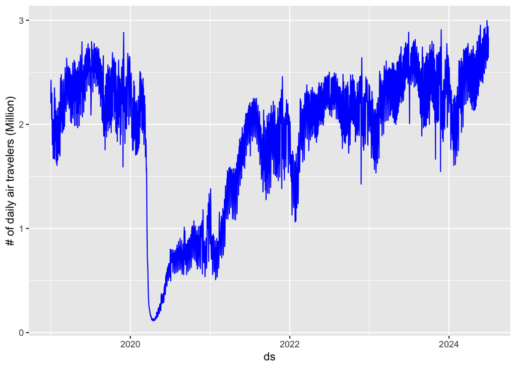

```r
# from H03c_prophet.R script
# setwd("~/Documents/workspace/harvard/CSCI-E-116/Assignment03/Data and Script 3")
tsa = read_excel("Data and Script 3/W09e_tsa.xlsx")
tsa_test = read_excel("Data and Script 3/W09e_tsa.xlsx", sheet="test")

tsa %>% ggplot() +
  geom_line(aes(x=ds, y=travel_train/1000000), color="blue") +
  ylab('# of daily air travelers (Million)')
```

```r
tsa = tsa %>% rename(y=travel_train)

covid = data_frame(
  holiday = 'covid',
  ds = seq(as.Date('2020-3-15'), to=as.Date('2022-3-1'), by='days'),
  lower_window = 0,
  upper_window = 1
)
m11 = prophet(tsa)#, holidays = covid, daily.seasonality = TRUE)
```

```
## Disabling daily seasonality. Run prophet with daily.seasonality=TRUE to override this.
```

```r
future = make_future_dataframe(m11, periods = 81) # Size of testset
tail(future)
```

```
##              ds
## 2084 2024-09-14
## 2085 2024-09-15
## 2086 2024-09-16
## 2087 2024-09-17
## 2088 2024-09-18
## 2089 2024-09-19
```

```r
forecast11 = predict(m11, future)
tail(forecast11[c('ds', 'yhat', 'yhat_lower', 'yhat_upper')])
```

```
##              ds    yhat yhat_lower yhat_upper
## 2084 2024-09-14 2362485    2089057    2647547
## 2085 2024-09-15 2666183    2390298    2949451
## 2086 2024-09-16 2598575    2299907    2853175
## 2087 2024-09-17 2308076    2032425    2590203
## 2088 2024-09-18 2391869    2120210    2677697
## 2089 2024-09-19 2625665    2331115    2923315
```

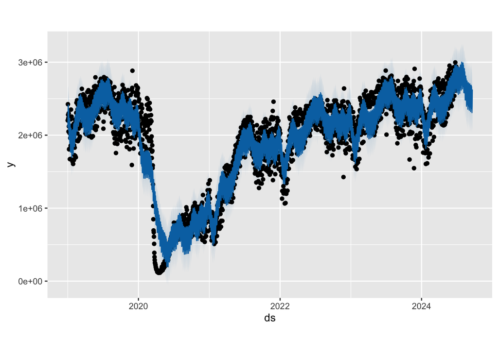

```r
plot(m11, forecast11)
```

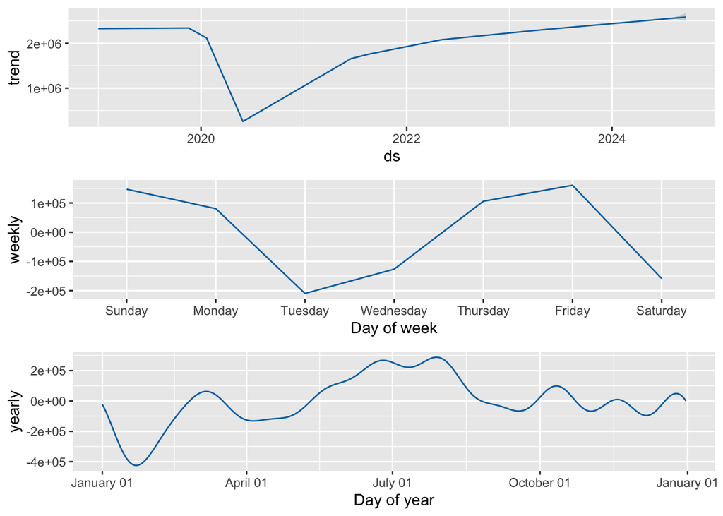

```r
prophet_plot_components(m11, forecast11)
```

```r
forecast11a = subset(forecast11, ds>=as.Date("2024-07-01"))
```

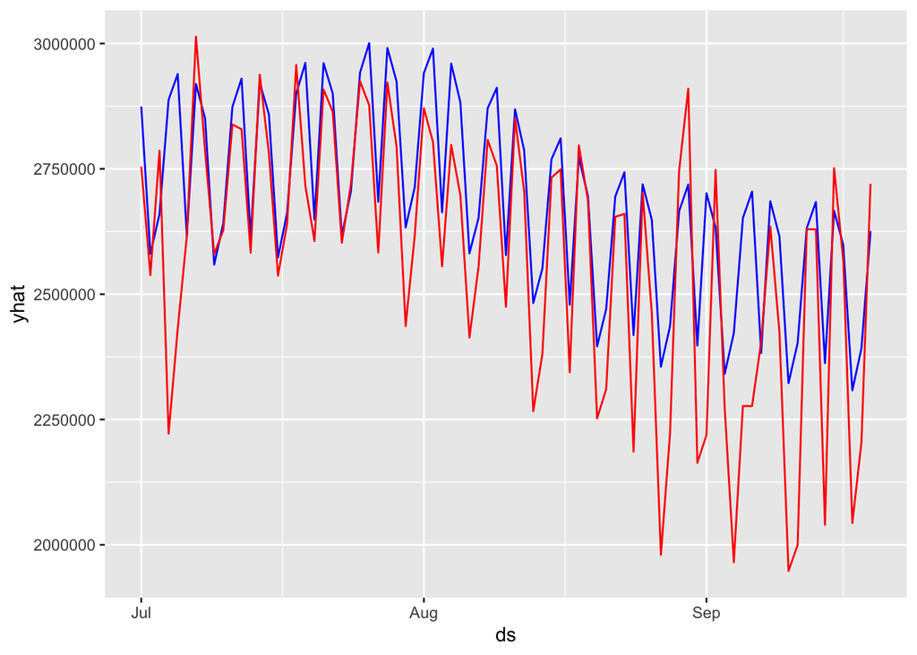

```r
ggplot() +
geom_line(data=forecast11a, aes(x=ds, y=yhat), color="blue") +
geom_line(data=tsa_test, aes(x=ds, y=travel_test), color="red")
```

```r
rmse11 = sqrt(mean((forecast11a$yhat-tsa_test$travel_test)^2))
```

RMSE = 1.9284978^{5}

### m11 Modified

Looking for the minimum RMSE by trying all the months in 2022

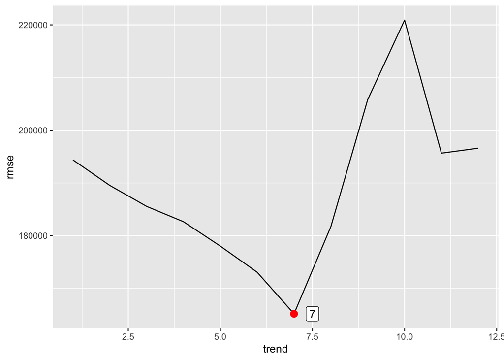

```r
min.rmse = data.frame(trend=1:12)
for (adj.month in 1:12){
  covid = data_frame(
    holiday = 'covid',
    ds = seq(as.Date('2020-3-15'), to=as.Date(
      paste(paste("2022",adj.month,sep="-"),"1", sep="-")
      ), by='days'),
    lower_window = 0,
    upper_window = 1
  )

  m11mod = prophet(tsa, holidays = covid, daily.seasonality = TRUE)

  future = make_future_dataframe(m11mod, periods = 81) # Size of testset
  tail(future)
  forecast11mod = predict(m11mod, future)
  tail(forecast11mod[c('ds', 'yhat', 'yhat_lower', 'yhat_upper')])
  # plot(m11, forecast11mod)
  #prophet_plot_components(m11mod, forecast11mod)

  forecast11amod = subset(forecast11mod, ds>=as.Date("2024-07-01"))

  # ggplot() +
  # geom_line(data=forecast11amod, aes(x=ds, y=yhat), color="blue") +
  # geom_line(data=tsa_test, aes(x=ds, y=travel_test), color="red")
  min.rmse$rmse[adj.month] = sqrt(mean((forecast11amod$yhat-tsa_test$travel_test)^2))

}
min.rmse |>
ggplot(aes(x=trend, y=rmse, label=trend)) +
  geom_line() +
  geom_point(data=min.rmse[which.min(min.rmse$rmse),], color="red", size=3) +
  geom_label(data=min.rmse[which.min(min.rmse$rmse),], nudge_x = 0.5)
```

Building the new output for July (month 7), which provides the minimum RMSE for our COVID end month within 2022.

(Lazily copied my code from above and shortened the list to just 7)

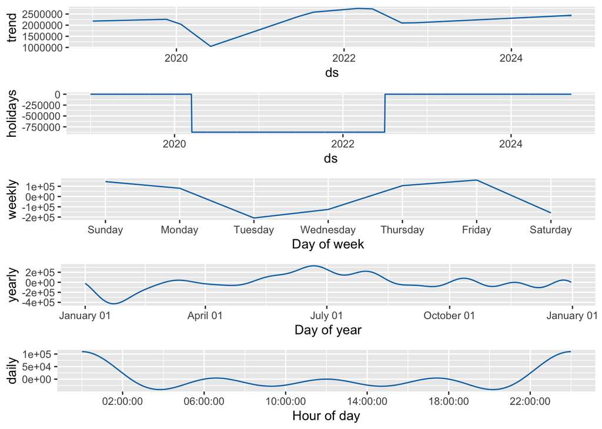

```r
for (adj.month in 7){
  covid = data_frame(
    holiday = 'covid',
    ds = seq(as.Date('2020-3-15'), to=as.Date(
      paste(paste("2022",adj.month,sep="-"),"1", sep="-")
      ), by='days'),
    lower_window = 0,
    upper_window = 1
  )

  m11mod = prophet(tsa, holidays = covid, daily.seasonality = TRUE)

  future = make_future_dataframe(m11mod, periods = 81) # Size of testset
  tail(future)
  forecast11mod = predict(m11mod, future)
  tail(forecast11mod[c('ds', 'yhat', 'yhat_lower', 'yhat_upper')])
  plot(m11, forecast11mod)
  prophet_plot_components(m11mod, forecast11mod)

  forecast11amod = subset(forecast11mod, ds>=as.Date("2024-07-01"))

  ggplot() +
  geom_line(data=forecast11amod, aes(x=ds, y=yhat), color="blue") +
  geom_line(data=tsa_test, aes(x=ds, y=travel_test), color="red")
  rmse11mod = sqrt(mean((forecast11amod$yhat-tsa_test$travel_test)^2))
}
```

RMSE value is 1.65163^{5}

Now to remove the federal holidays for our timeframe.

```r
# New Year’s Day January 1
on_newyears = hol_new_years_day()
# Martin Luther King’s Birthday 3rd Monday in January
on_mlk = hol_us_martin_luther_king_junior_day()
# Washington’s Birthday 3rd Monday in February
on_presday = hol_us_presidents_day()
# Memorial Day last Monday in May
on_memorial = hol_us_memorial_day()
# Juneteenth National Independence Day June 19
on_juneteenth = hol_us_juneteenth()
# Independence Day July 4
on_indep = hol_us_independence_day()
# Labor Day 1st Monday in September
on_labor = hol_us_labor_day()
# Columbus Day 2nd Monday in October
on_columb = hol_us_indigenous_peoples_day()
# Veterans’ Day November 11
on_vets = hol_us_veterans_day()
# Thanksgiving Day 4th Thursday in November
on_thanks = hol_us_thanksgiving()
# Christmas Day December 25
on_christmas = hol_christmas()

sched = runion(on_newyears, on_mlk, on_presday, on_memorial, on_juneteenth,
               on_indep, on_labor, on_columb, on_vets, on_thanks, on_christmas)

fed.holidays = alma_events(sched, year = 2019:2024)
```

```r
  covid = data_frame(
    holiday = 'covid',
    ds = seq(as.Date('2020-3-15'), to=as.Date("2022-7-1"), by='days'),
    lower_window = 0,
    upper_window = 1
  )

  fed.holidays.df = data_frame(
    holiday = "fed.holidays",
    ds = fed.holidays,
    lower_window = 0,
    upper_window =1
  )
  all.holidays = merge(covid, fed.holidays.df)

  m11mod = prophet(tsa, holidays = all.holidays, daily.seasonality = TRUE)
  future = make_future_dataframe(m11mod, periods = 81) # Size of testset
  tail(future)
```

```
##              ds
## 2084 2024-09-14
## 2085 2024-09-15
## 2086 2024-09-16
## 2087 2024-09-17
## 2088 2024-09-18
## 2089 2024-09-19
```

```r
  forecast11mod = predict(m11mod, future)
  tail(forecast11mod[c('ds', 'yhat', 'yhat_lower', 'yhat_upper')])
```

```
##              ds    yhat yhat_lower yhat_upper
## 2084 2024-09-14 2352269    2068931    2623396
## 2085 2024-09-15 2655914    2383237    2912946
## 2086 2024-09-16 2588227    2312337    2880374
## 2087 2024-09-17 2297715    2016758    2587873
## 2088 2024-09-18 2381449    2102849    2659584
## 2089 2024-09-19 2615184    2320704    2897474
```

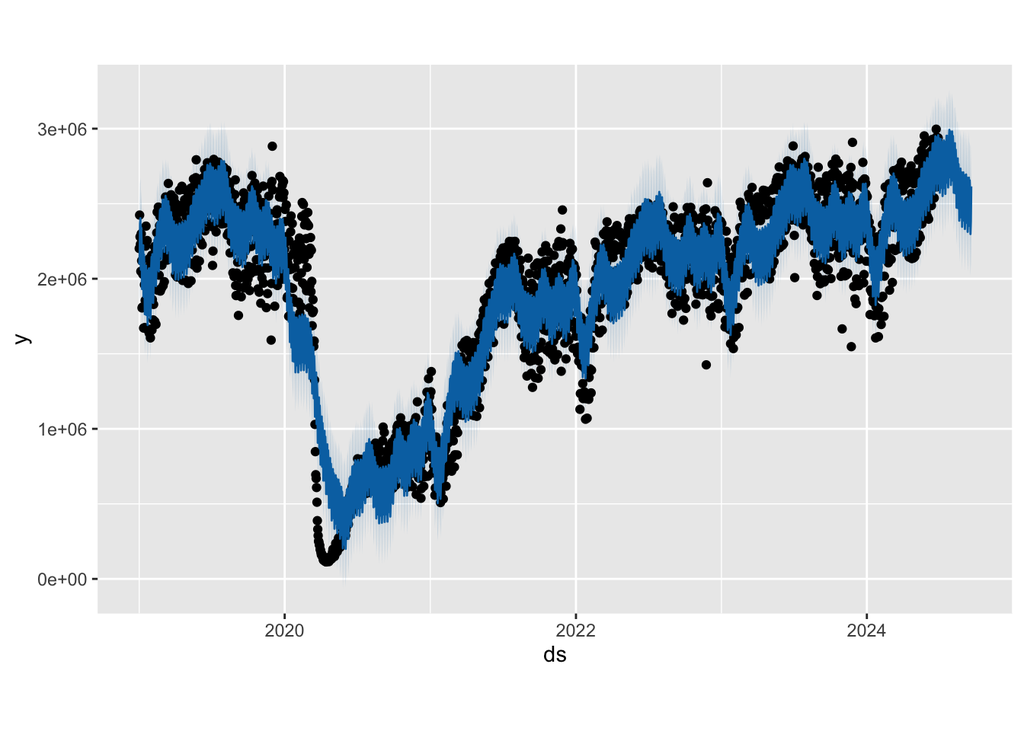

```r
  plot(m11, forecast11mod)
```

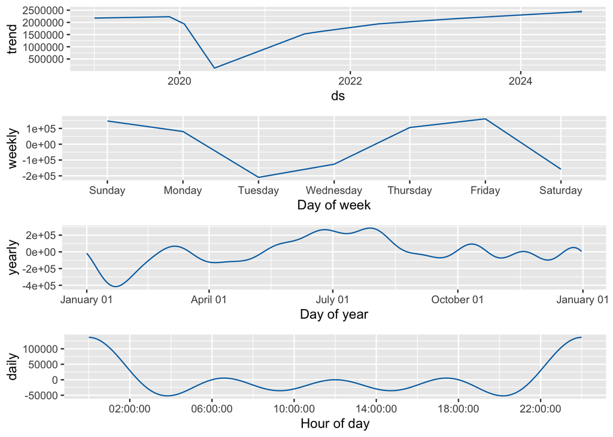

```r
  prophet_plot_components(m11mod, forecast11mod)
```

```r
  forecast11amod = subset(forecast11mod, ds>=as.Date("2024-07-01"))
```

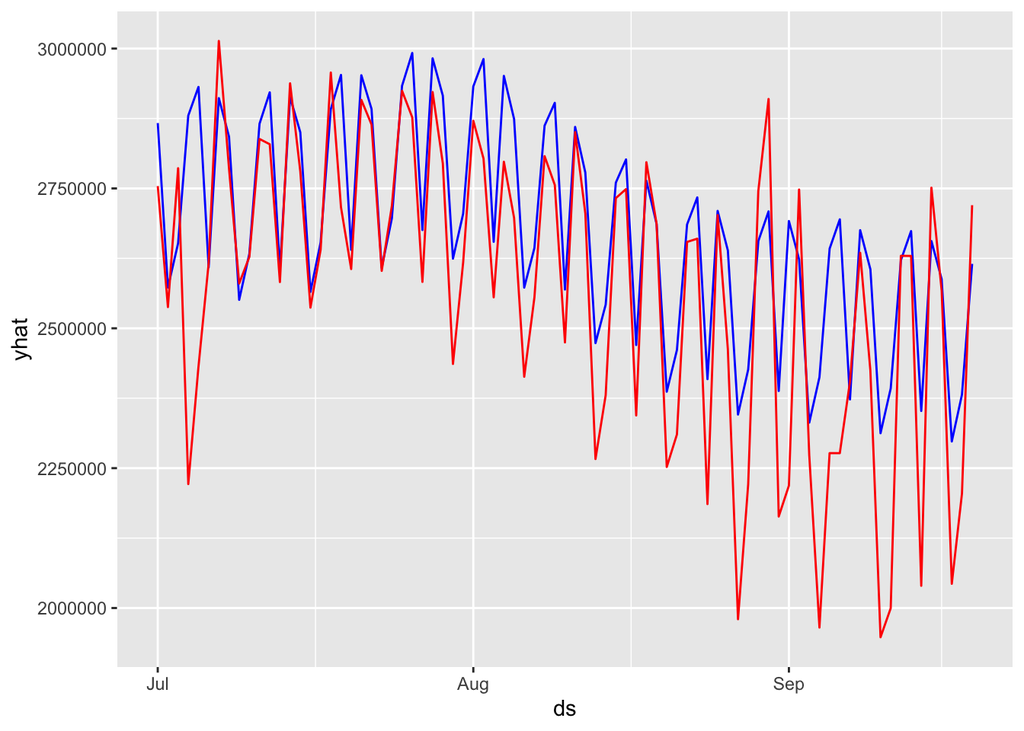

```r
  ggplot() +
  geom_line(data=forecast11amod, aes(x=ds, y=yhat), color="blue") +
  geom_line(data=tsa_test, aes(x=ds, y=travel_test), color="red")
```

```r
  rmse11mod = sqrt(mean((forecast11amod$yhat-tsa_test$travel_test)^2))
```

# Part B: **Model/Features Selection**

## Model 1

### Data Ingress

```r
c.data = read.csv("new2.csv")
summary(c.data) %>%
  kbl() %>%
  kable_styling()
```

|  | X | county | name | statename | stateid | case | death | case0520 | death0520 | population | area | NAME | sparent_m | sparent_f | hhage65a | hhsize | college_higher | disable | disable65a | fborn | fb_nonc | computer | broadband | lcp | ur | commute_p | commute_ms | wfh | eea_hhs | … |
| --- | --- | --- | --- | --- | --- | --- | --- | --- | --- | --- | --- | --- | --- | --- | --- | --- | --- | --- | --- | --- | --- | --- | --- | --- | --- | --- | --- | --- | --- | --- |
|  | Min. : 1.0 | Min. : 1001 | Length:3142 | Length:3142 | Min. : 1.00 | Min. : 0 | Min. : 0.0 | Min. : 0 | Min. : 0.0 | Min. : 86 | Min. : 0.0 | Length:3142 | Min. : 0.000 | Min. : 0.000 | Min. : 0.000 | Min. :1.410 | Min. : 0.00 | Min. : 4.00 | Min. :11.50 | Min. : 0.000 | Min. : 0.00 | Min. :43.20 | Min. :34.80 | Min. :15.40 | Min. : 0.000 | Min. : 0.0000 | Min. : 5.10 | Min. : 0.000 | Min. : 0.00 | … |
|  | 1st Qu.: 786.2 | 1st Qu.:18178 | Class :character | Class :character | 1st Qu.:18.00 | 1st Qu.: 2937 | 1st Qu.: 44.0 | 1st Qu.: 2937 | 1st Qu.: 44.0 | 1st Qu.: 10902 | 1st Qu.: 431.6 | Class :character | 1st Qu.: 0.900 | 1st Qu.: 3.300 | 1st Qu.: 7.200 | 1st Qu.:2.340 | 1st Qu.:15.32 | 1st Qu.:12.90 | 1st Qu.:32.70 | 1st Qu.: 1.400 | 1st Qu.: 43.40 | 1st Qu.:82.10 | 1st Qu.:70.50 | 1st Qu.:53.20 | 1st Qu.: 3.600 | 1st Qu.: 0.1000 | 1st Qu.:19.80 | 1st Qu.: 3.200 | 1st Qu.:20.23 | … |
|  | Median :1571.5 | Median :29176 | Mode :character | Mode :character | Median :29.00 | Median : 7462 | Median : 104.5 | Median : 7462 | Median : 104.5 | Median : 25726 | Median : 614.8 | Mode :character | Median : 1.300 | Median : 4.300 | Median : 8.400 | Median :2.480 | Median :19.60 | Median :15.50 | Median :37.10 | Median : 2.700 | Median : 55.40 | Median :86.30 | Median :76.45 | Median :58.80 | Median : 4.900 | Median : 0.3000 | Median :23.70 | Median : 4.500 | Median :22.80 | … |
|  | Mean :1571.5 | Mean :30384 | NA | NA | Mean :30.28 | Mean : 29830 | Mean : 315.8 | Mean : 29830 | Mean : 315.8 | Mean : 104468 | Mean : 1120.0 | NA | Mean : 1.316 | Mean : 4.687 | Mean : 8.457 | Mean :2.513 | Mean :21.98 | Mean :15.96 | Mean :37.82 | Mean : 4.769 | Mean : 54.79 | Mean :85.43 | Mean :75.40 | Mean :58.09 | Mean : 5.293 | Mean : 0.9105 | Mean :23.85 | Mean : 5.116 | Mean :23.19 | … |
|  | 3rd Qu.:2356.8 | 3rd Qu.:45080 | NA | NA | 3rd Qu.:45.00 | 3rd Qu.: 19634 | 3rd Qu.: 246.8 | 3rd Qu.: 19634 | 3rd Qu.: 246.8 | 3rd Qu.: 68073 | 3rd Qu.: 922.4 | NA | 3rd Qu.: 1.600 | 3rd Qu.: 5.700 | 3rd Qu.: 9.700 | 3rd Qu.:2.630 | 3rd Qu.:26.00 | 3rd Qu.:18.60 | 3rd Qu.:42.10 | 3rd Qu.: 5.700 | 3rd Qu.: 66.80 | 3rd Qu.:89.70 | 3rd Qu.:81.40 | 3rd Qu.:63.90 | 3rd Qu.: 6.500 | 3rd Qu.: 0.7000 | 3rd Qu.:27.60 | 3rd Qu.: 6.300 | 3rd Qu.:25.80 | … |
|  | Max. :3142.0 | Max. :56045 | NA | NA | Max. :56.00 | Max. :3420119 | Max. :34356.0 | Max. :3420119 | Max. :34356.0 | Max. :10039107 | Max. :157121.3 | NA | Max. :16.800 | Max. :16.200 | Max. :22.100 | Max. :5.140 | Max. :77.60 | Max. :36.80 | Max. :83.30 | Max. :53.700 | Max. :100.00 | Max. :98.30 | Max. :96.00 | Max. :81.60 | Max. :27.200 | Max. :61.2000 | Max. :52.60 | Max. :34.100 | Max. :57.90 | … |
|  | NA | NA | NA | NA | NA | NA | NA | NA | NA | NA | NA’s :2 | NA | NA | NA | NA | NA | NA | NA | NA | NA | NA’s :13 | NA | NA | NA | NA | NA | NA’s :1 | NA | NA | … |

### Correlation

```r
corr.data = round(cor(
  c.data$deathp,
  subset(c.data,select=-c(name,statename,NAME,deathp,X)),
  use="na.or.complete"
  ),2)

corr.df = as.data.frame(as.table(corr.data))
corr.df['abs_Freq'] = abs(corr.df$Freq)
corr.df %>%
  replace(is.na(.), 1.0) %>%
  arrange(desc(abs_Freq)) %>%
  filter(abs_Freq >= 0.9) %>%
  kable()
```

| Var1 | Var2 | Freq | abs_Freq |
| --- | --- | --- | --- |
| A | deathp520 | 1 | 1 |

So, the one variable with a correlation magnitude greater that 0.9 is $deathp520$ and will be remove. This makes sense since the variable are very closely related. Also removing the location indicators since they’re all categorical variables, adding a ton of factors to an already large number of predictors. Even the numeric location variables would have to be treated as categories since their numbers don’t make any sense in a continuous numerical observation.

### Initial Model Generation

```r
no.na.data = na.omit(c.data)

set.seed(222)

# Setting up a training and test dataset
ind <- sample(2, nrow(no.na.data), replace = TRUE, prob = c(0.7, 0.3))
train <- no.na.data[ind==1,]
test <- no.na.data[ind==2,]


m01 = lm(deathp ~ . -deathp520 -X - name - NAME -statename -stateid -county, data = train)
summary(m01)
```

```
##
## Call:
## lm(formula = deathp ~ . - deathp520 - X - name - NAME - statename -
##     stateid - county, data = train)
##
## Residuals:
##      Min       1Q   Median       3Q      Max
## -11742.4   -300.5      8.9    332.9   3107.9
##
## Coefficients: (11 not defined because of singularities)
##                  Estimate Std. Error t value Pr(>|t|)
## (Intercept)     6.947e+03  2.450e+03   2.836 0.004629 **
## case           -1.884e-03  9.018e-04  -2.089 0.036869 *
## death           6.465e-01  7.717e-02   8.378  < 2e-16 ***
## case0520               NA         NA      NA       NA
## death0520              NA         NA      NA       NA
## population      6.783e-03  5.205e-03   1.303 0.192675
## area           -1.003e-02  1.770e-02  -0.567 0.570902
## sparent_m       4.426e+01  3.283e+01   1.348 0.177797
## sparent_f      -7.367e+00  1.804e+01  -0.408 0.683110
## hhage65a       -7.715e+00  1.653e+01  -0.467 0.640774
## hhsize         -2.643e+02  2.240e+02  -1.180 0.238075
## college_higher  3.014e+01  1.230e+01   2.450 0.014395 *
## disable         3.872e-01  1.301e+01   0.030 0.976266
## disable65a      1.613e+00  6.088e+00   0.265 0.791140
## fborn          -3.860e+01  9.082e+00  -4.250 2.26e-05 ***
## fb_nonc        -2.519e+00  1.235e+00  -2.039 0.041609 *
## computer       -1.018e+01  8.607e+00  -1.183 0.237061
## broadband       6.502e+00  5.981e+00   1.087 0.277208
## lcp             4.648e+00  5.981e+00   0.777 0.437179
## ur              2.345e+01  1.284e+01   1.827 0.067874 .
## commute_p       2.330e+01  1.345e+01   1.732 0.083386 .
## commute_ms      7.230e+00  5.850e+00   1.236 0.216695
## wfh            -1.167e+01  1.067e+01  -1.094 0.274225
## eea_hhs        -1.305e-01  6.120e+00  -0.021 0.982993
## eea_lh         -1.246e+01  8.802e+00  -1.416 0.156941
## mincome        -3.185e-03  5.392e-03  -0.591 0.554745
## fstamp         -1.896e+01  7.619e+00  -2.489 0.012910 *
## hi_pub         -3.063e+00  7.001e+00  -0.437 0.661818
## hi_no           2.458e+01  1.170e+01   2.101 0.035818 *
```

[output cut: 60 more lines]

```
## healthyfood     1.466e+01  3.574e+01   0.410 0.681744
## pinactivity    -1.697e+00  5.118e+00  -0.332 0.740168
## exerciseo       3.729e+00  1.258e+00   2.965 0.003069 **
## drinking       -3.198e+01  9.627e+00  -3.322 0.000914 ***
## smoking         2.689e+01  1.467e+01   1.833 0.066989 .
## lowbirthw       5.043e+00  1.835e+01   0.275 0.783499
## pcdoctor        4.138e-01  7.705e-01   0.537 0.591273
## hosp            2.013e-02  1.326e-02   1.518 0.129310
## vcrime          3.052e-01  1.241e-01   2.460 0.013996 *
## ---
## Signif. codes:  0 '***' 0.001 '**' 0.01 '*' 0.05 '.' 0.1 ' ' 1
##
## Residual standard error: 709.1 on 1655 degrees of freedom
## Multiple R-squared:  0.8139, Adjusted R-squared:  0.8042
## F-statistic: 84.17 on 86 and 1655 DF,  p-value: < 2.2e-16
```

### Stepwise Treatment

```r
m01.step = stepAIC(m01, direction="both")
```

Verbose output suppressed.

### ANOVA Summary

And here’s the ANOVA analysis of the stepwise model search:

```r
m01.step$anova
```

```
## Stepwise Model Path
## Analysis of Deviance Table
##
## Initial Model:
## deathp ~ (X + county + name + statename + stateid + case + death +
##     case0520 + death0520 + population + area + NAME + sparent_m +
##     sparent_f + hhage65a + hhsize + college_higher + disable +
##     disable65a + fborn + fb_nonc + computer + broadband + lcp +
##     ur + commute_p + commute_ms + wfh + eea_hhs + eea_lh + mincome +
##     fstamp + hi_pub + hi_no + hi_no_neea + hi_no_nlc + poverty +
##     rentalu + rental_size + mrent + mhomeprice + pop + mage +
##     a85a + a7584 + a6574 + a6064 + a5559 + a4554 + a3544 + a2534 +
##     a2024 + a1519 + black + asian + aindian + latino + chci +
##     sparent + a75a + a65a + a60a + a5564 + a3554 + a2034 + afford +
##     pdensity + casep + casep520 + deathp520 + candidatevotes +
##     totalvotes + demv + doctor + gym + grocery + nursehome +
##     meatpack + liquor + airport + travel + cfr + p_doctor + p_gym +
##     p_grocery + p_nursehome + p_meatpack + p_liquor + p_airport +
##     p_travel + hi_no_eea + prematured + poorhealth + unhealthyd +
##     obesity + healthyfood + pinactivity + exerciseo + drinking +
##     smoking + lowbirthw + pcdoctor + hosp + vcrime) - deathp520 -
##     X - name - NAME - statename - stateid - county
##
## Final Model:
## deathp ~ case + death + sparent_m + hhsize + college_higher +
##     fborn + fb_nonc + ur + commute_p + eea_lh + fstamp + hi_no +
##     hi_no_neea + hi_no_nlc + poverty + mrent + pop + a85a + a6574 +
##     a4554 + a3544 + a2534 + a1519 + black + asian + aindian +
##     latino + chci + pdensity + casep + candidatevotes + demv +
##     gym + grocery + nursehome + travel + cfr + p_nursehome +
##     prematured + unhealthyd + exerciseo + drinking + smoking +
##     hosp + vcrime
##
##
##             Step Df    Deviance Resid. Df Resid. Dev      AIC
## 1                                    1655  832233485 22953.85
## 2    - hi_no_eea  0      0.0000      1655  832233485 22953.85
## 3     - casep520  0      0.0000      1655  832233485 22953.85
## 4        - a2034  0      0.0000      1655  832233485 22953.85
## 5        - a3554  0      0.0000      1655  832233485 22953.85
```

[output cut: 33 more lines]

```
## 39  - totalvotes  1 417130.9016      1682  835286698 22906.22
## 40       - a6064  1 401950.8895      1683  835688649 22905.06
## 41  - poorhealth  1 482920.8899      1684  836171570 22904.07
## 42     - rentalu  1 549552.4098      1685  836721123 22903.21
## 43  - commute_ms  1 474922.3626      1686  837196045 22902.20
## 44       - p_gym  1 595186.1020      1687  837791231 22901.44
## 45   - broadband  1 578281.0971      1688  838369512 22900.64
## 46    - computer  1 191015.9660      1689  838560528 22899.04
## 47  - p_meatpack  1 609363.7359      1690  839169892 22898.30
## 48         - wfh  1 715644.7444      1691  839885537 22897.79
## 49  - population  1 645280.9931      1692  840530818 22897.13
## 50     - obesity  1 808244.0034      1693  841339062 22896.80
## 51      - afford  1 925244.9886      1694  842264306 22896.72
## 52    - p_doctor  1 773492.9155      1695  843037799 22896.32
## 53      - doctor  1 393063.7456      1696  843430863 22895.13
```

```r
summary(m01.step)
```

```
##
## Call:
## lm(formula = deathp ~ case + death + sparent_m + hhsize + college_higher +
##     fborn + fb_nonc + ur + commute_p + eea_lh + fstamp + hi_no +
##     hi_no_neea + hi_no_nlc + poverty + mrent + pop + a85a + a6574 +
##     a4554 + a3544 + a2534 + a1519 + black + asian + aindian +
##     latino + chci + pdensity + casep + candidatevotes + demv +
##     gym + grocery + nursehome + travel + cfr + p_nursehome +
##     prematured + unhealthyd + exerciseo + drinking + smoking +
##     hosp + vcrime, data = train)
##
## Residuals:
##      Min       1Q   Median       3Q      Max
## -12032.4   -305.2     11.6    335.4   3018.0
##
## Coefficients:
##                  Estimate Std. Error t value Pr(>|t|)
## (Intercept)     7.236e+03  1.677e+03   4.315 1.69e-05 ***
## case           -2.299e-03  7.710e-04  -2.982 0.002905 **
## death           5.880e-01  6.664e-02   8.823  < 2e-16 ***
## sparent_m       4.628e+01  3.199e+01   1.446 0.148252
## hhsize         -3.234e+02  1.325e+02  -2.441 0.014744 *
## college_higher  3.188e+01  1.056e+01   3.019 0.002572 **
## fborn          -3.916e+01  8.266e+00  -4.738 2.34e-06 ***
## fb_nonc        -2.471e+00  1.195e+00  -2.068 0.038824 *
## ur              2.510e+01  1.211e+01   2.072 0.038421 *
## commute_p       3.105e+01  1.173e+01   2.647 0.008188 **
## eea_lh         -1.696e+01  6.906e+00  -2.456 0.014159 *
## fstamp         -1.865e+01  6.620e+00  -2.818 0.004892 **
## hi_no           2.672e+01  1.108e+01   2.412 0.015963 *
## hi_no_neea     -2.388e+00  1.455e+00  -1.641 0.101063
## hi_no_nlc      -1.723e+01  5.798e+00  -2.972 0.003002 **
## poverty        -1.773e+01  8.410e+00  -2.108 0.035169 *
## mrent          -4.781e-01  1.726e-01  -2.770 0.005664 **
## pop            -1.590e-03  4.377e-04  -3.632 0.000289 ***
## a85a            1.430e+02  3.611e+01   3.959 7.83e-05 ***
## a6574          -5.040e+01  1.770e+01  -2.848 0.004457 **
## a4554           3.429e+01  1.841e+01   1.862 0.062774 .
## a3544          -7.645e+01  2.039e+01  -3.749 0.000184 ***
## a2534          -5.074e+01  1.703e+01  -2.980 0.002927 **
```

[output cut: 14 more lines]

```
## cfr             1.328e+01  2.838e-01  46.783  < 2e-16 ***
## p_nursehome     1.780e+02  4.282e+01   4.158 3.37e-05 ***
## prematured      7.307e-02  1.436e-02   5.089 4.00e-07 ***
## unhealthyd      1.076e+02  6.625e+01   1.624 0.104524
## exerciseo       3.767e+00  1.184e+00   3.181 0.001492 **
## drinking       -3.064e+01  8.861e+00  -3.458 0.000558 ***
## smoking         2.162e+01  1.251e+01   1.728 0.084243 .
## hosp            2.584e-02  1.243e-02   2.079 0.037811 *
## vcrime          2.977e-01  1.179e-01   2.525 0.011666 *
## ---
## Signif. codes:  0 '***' 0.001 '**' 0.01 '*' 0.05 '.' 0.1 ' ' 1
##
## Residual standard error: 705.2 on 1696 degrees of freedom
## Multiple R-squared:  0.8114, Adjusted R-squared:  0.8064
## F-statistic: 162.1 on 45 and 1696 DF,  p-value: < 2.2e-16
```

### Prediction

```r
p1 = predict(m01.step, train)
rmse01.train = round(sqrt(mean((p1-train$deathp)^2)),2)

p1.test = predict(m01.step, test)
rmse01.test = round(sqrt(mean((p1.test-test$deathp)^2)),2)
```

## Model 2

### Random Forest

```r
rf <- randomForest(deathp ~ . -deathp520 -X - name - NAME -statename -stateid -county, data=train, proximity=TRUE)
```

```r
rf
```

```
##
## Call:
##  randomForest(formula = deathp ~ . - deathp520 - X - name - NAME -      statename - stateid - county, data = train, proximity = TRUE)
##                Type of random forest: regression
##                      Number of trees: 500
## No. of variables tried at each split: 32
##
##           Mean of squared residuals: 205584.8
##                     % Var explained: 91.99
```

```r
p2 = predict(rf, train)
rmse02.train = round(sqrt(mean((p2-train$deathp)^2)),2)

p2.test = predict(rf, test)
rmse02.test = round(sqrt(mean((p2.test-test$deathp)^2)),2)
```

## Comparison

Our RSME values were as follows:

[output not shown]

It would appear that the RMSE for the Baseline Time Series Model is significantly higher than the linear regression and random forest models from the non-time series models, even after some optimization. I believe the major factor leading to this discrepancy is the much higher number of predictors in both the regression and forest models versus the time series. These additional predictors give us a wider variety of information to correlate a response as opposed to the time series model only having the single statistic over time to predict the future values. The time series data also has a significant random walk impact, which is very hard to predict effectively.